# Replication Report for Study 2 by Galperin, Hahl, Stering, & Guo (2020, Administrative Science Quarterly)

### Exploratory Analyses

#### Two-way ANOVA

```r
# Check normality assumption (QQ plot)
#ggqqplot(data_clean, "offer_score", ggtheme = theme_bw()) +
#  facet_grid(Overqual ~ Commitment)
```

```r
result_aov <- data_clean %>% anova_test(offer_score ~ Overqual*Commitment)
```

```
## Coefficient covariances computed by hccm()
```

```r
result_aov
```

```
## ANOVA Table (type II tests)
##
##                Effect DFn DFd     F     p p<.05   ges
## 1            Overqual   1 133 1.564 0.213       0.012
## 2          Commitment   1 133 0.705 0.403       0.005
## 3 Overqual:Commitment   1 133 0.661 0.418       0.005
```

The two-way ANOVA results show that there was no statitically significant interaction between Capability and Commitment condition for the likelihood of getting an offer.

#### Two-way ANCOVA

Since the results of t-tests and two-way ANOVA were not statistically significant, I examined the possibility of other factors, such as work experience and age, interfering with the results.

##### Check Linearity Assumptions

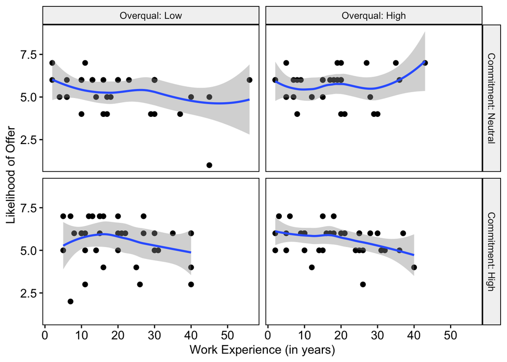

```r
ggscatter(
  data = data_clean, x = "workexperience", y = "offer_score",
  facet.by = c("Commitment", "Overqual"),
  short.panel.labs = F,
  xlab = c("Work Experience (in years)"),
  ylab = c("Likelihood of Offer"),
) +
  stat_smooth(method = "loess", span = 0.9)
```

##### Homogeneity of Regression Slopes

This assumption checks that there is not significant interaction betwen the covariate and the grouping variables.

```r
data_clean %>%
  anova_test(
    offer_score ~ workexperience + Overqual + Commitment + Overqual*Commitment + workexperience*Overqual + workexperience*Commitment + workexperience*Commitment*Overqual
  )
```

```
## Coefficient covariances computed by hccm()
```

```
## ANOVA Table (type II tests)
##
##                               Effect DFn DFd     F     p p<.05   ges
## 1                     workexperience   1 129 5.647 0.019     * 0.042
## 2                           Overqual   1 129 1.022 0.314       0.008
## 3                         Commitment   1 129 0.679 0.412       0.005
## 4                Overqual:Commitment   1 129 0.720 0.398       0.006
## 5            workexperience:Overqual   1 129 0.814 0.369       0.006
## 6          workexperience:Commitment   1 129 0.806 0.371       0.006
## 7 workexperience:Overqual:Commitment   1 129 2.002 0.160       0.015
```

I already know that there is no statistically significant interaction effect between Capability (Overqual) and Commitment. However, just as a sanity check, I ran another ANOVA to show that there is no significant interaction between Capability (Overqual) and Commitment here.

##### Interaction Effect after Controlling for Participant’s Work Experience (ANCOVA)

```r
work_aov <- data_clean %>%
  anova_test(offer_score ~ workexperience + Overqual*Commitment)
```

```
## Coefficient covariances computed by hccm()
```

```r
get_anova_table(work_aov)
```

```
## ANOVA Table (type II tests)
##
##                Effect DFn DFd     F     p p<.05   ges
## 1      workexperience   1 132 5.629 0.019     * 0.041
## 2            Overqual   1 132 0.995 0.320       0.007
## 3          Commitment   1 132 0.720 0.398       0.005
## 4 Overqual:Commitment   1 132 0.561 0.455       0.004
```

There was no statistically significant interaction between Capability and Commitment on the likelihood of getting an offer after controlling for participant’s work experience (in years).

##### Interaction Effect after Controlling for Participant’s Age (ANCOVA)

```r
age_aov <- data_clean %>%
  anova_test(offer_score ~ Age + Overqual*Commitment)
```

```
## Coefficient covariances computed by hccm()
```

```r
get_anova_table(age_aov)
```

```
## ANOVA Table (type II tests)
##
##                Effect DFn DFd     F     p p<.05   ges
## 1                 Age   1 132 4.492 0.036     * 0.033
## 2            Overqual   1 132 1.103 0.295       0.008
## 3          Commitment   1 132 0.781 0.379       0.006
## 4 Overqual:Commitment   1 132 0.470 0.494       0.004
```

After adjusting for participant’s age, I found no statistically significant interaction between Capability and Commitment on the likelihood of getting an offer.